# Voxelwise segmentation with U-Net 2-D

## [Dice similarity coefficient](https://radiopaedia.org/articles/dice-similarity-coefficient).

The *Dice similarity coefficient*, also known as the *Sørensen–Dice index* or simply *Dice coefficient*, is a statistical tool which measures the similarity between two sets of data.

The equation for this concept is:
$$2\cdot\frac{|X ∩ Y|}{|X| + |Y|}$$
where X and Y are two sets a set with vertical bars either side refers to the cardinality of the set, i.e. the number of elements in that set, e.g. |X| means the number of elements in set X, ∩ is used to represent the intersection of two sets, and means the elements that are common to both sets.

This index has become arguably the most broadly used tool in the validation of image segmentation algorithms created with AI.

### Segmentations to something readable by the optimization process

An example of images segmented into two parts.

```r
groundTruthSegmentations = array(
  c(1, rep(0:1, times = 12)), dim = c(1, 5, 5)
)
cat(crayon::bgCyan('groundTruthSegmentations\n'))
```

```
#> groundTruthSegmentations
```

```r
str(groundTruthSegmentations)
```

```
#>  num [1, 1:5, 1:5] 1 0 1 0 1 0 1 0 1 0 ...
```

```r
segmentationLabels2 = c(0, 1)
cat(crayon::bgCyan('segmentationLabels\n'))
```

```
#> segmentationLabels
```

```r
str(segmentationLabels2)
```

```
#>  num [1:2] 0 1
```

```r
segmentationLabels = segmentationLabels2
numberOfLabels <- length(segmentationLabels)
dimSegmentations <- dim(groundTruthSegmentations)

imageDimension <- 2
if (length(dimSegmentations) == 4) {
  imageDimension <- 3
}
if (numberOfLabels < 2) {
  stop("At least two segmentation labels need to be specified.")
}

yEncoded <- array(0, dim = c(dimSegmentations, numberOfLabels))

for (i in seq_len(numberOfLabels)) {
  labelY <- groundTruthSegmentations
  labelY[which(groundTruthSegmentations == segmentationLabels[i])] <- 1L
  labelY[which(groundTruthSegmentations != segmentationLabels[i])] <- 0L
  if (imageDimension == 2) {
    yEncoded[, , , i] <- labelY
  }
  else {
    yEncoded[, , , , i] <- labelY
  }
}

cat(crayon::bgCyan('return(yEncoded)\n'))
```

```
#> return(yEncoded)
```

```r
str(yEncoded)
```

```
#>  num [1, 1:5, 1:5, 1:2] 0 1 0 1 0 1 0 1 0 1 ...
```

Below we use the `encodeUnet` function for translating the segmentations to something readable by the optimization process.

```r
encodeUnet <- function(groundTruthSegmentations, segmentationLabels)
```

```r
y_train <- encodeUnet(groundTruthSegmentations, segmentationLabels = segmentationLabels2)
cat(crayon::bgCyan('return(yEncoded)\n'))
```

```
#> return(yEncoded)
```

```r
str(y_train)
```

```
#>  num [1, 1:5, 1:5, 1:2] 0 1 0 1 0 1 0 1 0 1 ...
```

We wil use `y_train` array in examples below.

```r
multilabel_dice_coefficient_2d <- function (y_true, y_pred)
```

```r
# shape = (1, 10, 10, 2)
y_true <- y_train
y_pred <- 1 - y_train

smoothingFactor <- 1
K <- keras::backend()
K$set_image_data_format("channels_last")
y_dims <- unlist(K$int_shape(y_pred))     #  1 10 10 2
numberOfLabels <- y_dims[length(y_dims)]

y_true_permuted <- K$permute_dimensions(y_true, pattern = c(3L, 0L, 1L, 2L))
y_pred_permuted <- K$permute_dimensions(y_pred, pattern = c(3L, 0L, 1L, 2L))

cat(crayon::bgCyan('shape of y_true_permuted (y_pred_permuted)\n'))
```

```
#> shape of y_true_permuted (y_pred_permuted)
```

```r
str(y_true_permuted)
```

```
#> tf.Tensor(
#> [[[[0. 1. 0. 1. 0.]
#>    [1. 0. 1. 0. 1.]
#>    [0. 1. 0. 1. 0.]
#>    [1. 0. 1. 0. 1.]
#>    [0. 1. 0. 1. 0.]]]
#>
#>
#>  [[[1. 0. 1. 0. 1.]
#>    [0. 1. 0. 1. 0.]
#>    [1. 0. 1. 0. 1.]
#>    [0. 1. 0. 1. 0.]
#>    [1. 0. 1. 0. 1.]]]], shape=(2, 1, 5, 5), dtype=float64)
```

```r
y_true_label <- K$gather(y_true_permuted, indices = c(1L))
y_pred_label <- K$gather(y_pred_permuted, indices = c(1L))
y_true_label_f <- K$flatten(y_true_label)
y_pred_label_f <- K$flatten(y_pred_label)

cat(crayon::bgCyan('\ny_true_label_f and y_pred_label values\n'))
```

```
#>
#> y_true_label_f and y_pred_label values
```

```r
str(y_true_label_f)
```

```
#> tf.Tensor(
#> [1. 0. 1. 0. 1. 0. 1. 0. 1. 0. 1. 0. 1. 0. 1. 0. 1. 0. 1. 0. 1. 0. 1. 0.
#>  1.], shape=(25,), dtype=float64)
```

```r
str(y_pred_label_f)
```

```
#> tf.Tensor(
#> [0. 1. 0. 1. 0. 1. 0. 1. 0. 1. 0. 1. 0. 1. 0. 1. 0. 1. 0. 1. 0. 1. 0. 1.
#>  0.], shape=(25,), dtype=float64)
```

```r
intersection <- y_true_label_f * y_pred_label_f
union <- y_true_label_f + y_pred_label_f - intersection

cat(crayon::bgCyan('\nintersection and union\n'))
```

```
#>
#> intersection and union
```

```r
str(intersection)
```

```
#> tf.Tensor(
#> [0. 0. 0. 0. 0. 0. 0. 0. 0. 0. 0. 0. 0. 0. 0. 0. 0. 0. 0. 0. 0. 0. 0. 0.
#>  0.], shape=(25,), dtype=float64)
```

```r
str(union)
```

```
#> tf.Tensor(
#> [1. 1. 1. 1. 1. 1. 1. 1. 1. 1. 1. 1. 1. 1. 1. 1. 1. 1. 1. 1. 1. 1. 1. 1.
#>  1.], shape=(25,), dtype=float64)
```

```r
numerator <- K$sum(intersection)
denominator <- K$sum(union)

# skipped for mask
if (numberOfLabels > 2) {
  for (j in 2L:(numberOfLabels - 1L)) {
    y_true_label <- K$gather(y_true_permuted, indices = c(j))
    y_pred_label <- K$gather(y_pred_permuted, indices = c(j))
    y_true_label_f <- K$flatten(y_true_label)
    y_pred_label_f <- K$flatten(y_pred_label)
    intersection <- y_true_label_f * y_pred_label_f
    union <- y_true_label_f + y_pred_label_f - intersection
    numerator <- numerator + K$sum(intersection)
    denominator <- denominator + K$sum(union)
  }
}
unionOverlap <- numerator / denominator
cat(crayon::bgCyan('\nunionOverlap\n'))
```

```
#>
#> unionOverlap
```

```r
unionOverlap
```

```
#> tf.Tensor(0.0, shape=(), dtype=float64)
```

```r
cat(crayon::bgCyan('\nreturn value\n'))
```

```
#>
#> return value
```

```r
(2 * unionOverlap + smoothingFactor) / (1 + unionOverlap + smoothingFactor)
```

```
#> tf.Tensor(0.5, shape=(), dtype=float64)
```

```r
multilabel_dice_coefficient_2d(y_true, y_true)
```

```
#>
#> y_true:  num [1, 1:5, 1:5, 1:2] 0 1 0 1 0 1 0 1 0 1 ...
#> y_pred:  num [1, 1:5, 1:5, 1:2] 0 1 0 1 0 1 0 1 0 1 ...
#> tf.Tensor(1.0, shape=(), dtype=float64)
```

```r
multilabel_dice_coefficient_2d(y_true, 1 - y_true)
```

```
#>
#> y_true:  num [1, 1:5, 1:5, 1:2] 0 1 0 1 0 1 0 1 0 1 ...
#> y_pred:  num [1, 1:5, 1:5, 1:2] 1 0 1 0 1 0 1 0 1 0 ...
#> tf.Tensor(0.5, shape=(), dtype=float64)
```

Generate two random masks and compute their `multilabel_dice_coefficient_2d`.

```r
val1 <- sample(c(rep(0, times = 7500), rep(1, times = 2500)))
table(val1)
```

```
#> val1
#>    0    1
#> 7500 2500
```

```r
val2 <- sample(val1)
table(val2)
```

```
#> val2
#>    0    1
#> 7500 2500
```

```r
ar1 <- array(val1, dim = c(1, 100, 100))
ar2 <- array(val2, dim = c(1, 100, 100))

yr1 <- encodeUnet(ar1, c(0, 1))
yr2 <- encodeUnet(ar2, c(0, 1))
str(yr1)
```

```
#>  num [1, 1:100, 1:100, 1:2] 0 0 0 0 1 0 0 1 0 1 ...
```

```r
str(yr2)
```

```
#>  num [1, 1:100, 1:100, 1:2] 1 1 0 1 1 0 1 0 1 1 ...
```

```r
multilabel_dice_coefficient_2d(yr1, yr2)
```

```
#>
#> y_true:  num [1, 1:100, 1:100, 1:2] 0 0 0 0 1 0 0 1 0 1 ...
#> y_pred:  num [1, 1:100, 1:100, 1:2] 1 1 0 1 1 0 1 0 1 1 ...
#> tf.Tensor(0.5994881637875878, shape=(), dtype=float64)
```

### Plot B&W and color images – 2 labels

```r
segmentationLabels = c(0, 1)
numberOfLabels <- 2

dims = c(1, 5, 5)

ar25 = c(1, rep(c(0:1), times = 12))
table(ar25)
```

```
#> ar25
#>  0  1
#> 12 13
```

```r
y_ar25 = encodeUnet(array(ar25, dim = dims), segmentationLabels)

cat("# batchSize x width x height x number of labels\n")
```

```
#> # batchSize x width x height x number of labels
```

```r
str(y_ar25)
```

```
#>  num [1, 1:5, 1:5, 1:2] 0 1 0 1 0 1 0 1 0 1 ...
```

```r
y_ar25[1,,,1]
```

```
#>      [,1] [,2] [,3] [,4] [,5]
#> [1,]    0    1    0    1    0
#> [2,]    1    0    1    0    1
#> [3,]    0    1    0    1    0
#> [4,]    1    0    1    0    1
#> [5,]    0    1    0    1    0
```

```r
p1 <- plotColor(as.antsImage(y_ar25[1,,,1]))
p2 <- plotColor(as.antsImage(y_ar25[1,,,2]))
```

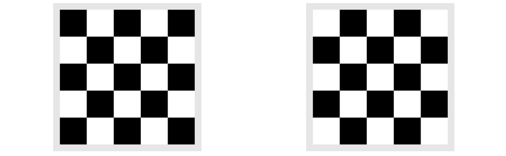

```r
cowplot::plot_grid(p1, p2, ncol = 2)
```

Use 3 separate channels to draw color images.

```r
zeros = array(rep(0, times = 5*5), dim = c(dims, 1))
ones = array(rep(1, times = 5*5), dim = c(dims, 1))

black3 <- as.antsImage(zeros[1,,,1])
white3 <- as.antsImage(ones[1,,,1])

p10 <- plotColor(black3)
p11 <- plotColor(white3)
p12 <- plotColor(list(white3, black3, black3))
p13 <- plotColor(list(white3, white3, black3))
```

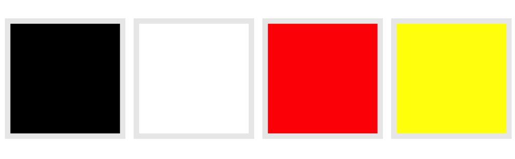

```r
cowplot::plot_grid(p10, p11, p12, p13, ncol = 4)
```

```r
trainingBatchSize <- 2

Y_true <- array(
  data = NA, dim = c(trainingBatchSize, c(5, 5))
)
Y_pred <- array(
  data = NA, dim = c(trainingBatchSize, c(5, 5))
)

val1 <- sample(c(rep(0, times = 15), rep(1, times = 10)))
table(val1)
```

```
#> val1
#>  0  1
#> 15 10
```

```r
val2 <- sample(val1)
table(val2)
```

```
#> val2
#>  0  1
#> 15 10
```

```r
Y_true[1,, ] <- as.array(val1)
Y_true[2,, ] <- as.array(val2)

Y_pred[1,, ] <- as.array(val2)
Y_pred[2,, ] <- as.array(val1)

str(Y_true)
```

```
#>  num [1:2, 1:5, 1:5] 1 0 0 0 1 0 0 1 0 1 ...
```

```r
Y_true <- encodeUnet(Y_true, segmentationLabels = c(0, 1))
Y_pred <- encodeUnet(Y_pred, segmentationLabels = c(0, 1))
str(Y_pred)
```

```
#>  num [1:2, 1:5, 1:5, 1:2] 1 0 1 1 1 0 0 1 0 1 ...
```

```r
multilabel_dice_coefficient_2d(Y_true, Y_pred)
```

```
#>
#> y_true:  num [1:2, 1:5, 1:5, 1:2] 0 1 1 1 0 1 1 0 1 0 ...
#> y_pred:  num [1:2, 1:5, 1:5, 1:2] 1 0 1 1 1 0 0 1 0 1 ...
#> tf.Tensor(0.6216216216216216, shape=(), dtype=float64)
```

## Perform simple background+tissue segmentation with tissue mask

```r
imageIDs <- c("r16", "r27", "r30", "r62", "r64", "r85")
trainingBatchSize <- length(imageIDs)

segmentationLabels <- c(0L, 1L)
numberOfLabels <- length(segmentationLabels)

# initialization <- paste0('KMeans[', numberOfLabels, ']')
(domainImage <- antsImageRead(getANTsRData(imageIDs[1])))
```

```
#> antsImage
#>   Pixel Type          : float
#>   Components Per Pixel: 1
#>   Dimensions          : 256x256
#>   Voxel Spacing       : 1x1
#>   Origin              : 0 0
#>   Direction           : 1 0 0 1
#>   Filename           : /Library/Frameworks/R.framework/Versions/4.0/Resources/library/ANTsRCore/extdata/r16slice.jpg
```

```r
X_train <- array(
  data = NA, dim = c(trainingBatchSize, dim(domainImage), 1)
)

Y_train <- array(
  data = NA, dim = c(trainingBatchSize, dim(domainImage))
)

str(X_train)
```

```
#>  logi [1:6, 1:256, 1:256, 1] NA NA NA NA NA NA ...
```

```r
str(Y_train)
```

```
#>  logi [1:6, 1:256, 1:256] NA NA NA NA NA NA ...
```

```r
for(i in seq_len(trainingBatchSize)) {
  image <- antsImageRead(getANTsRData(imageIDs[i]))
  mask <- getMask(image)
  X_train[i, , , 1] <- as.array(image * mask)
  Y_train[i, , ] <- as.array(mask)
}

Y_train <- encodeUnet(Y_train, segmentationLabels)
```

```r
str(X_train)
```

```
#>  num [1:6, 1:256, 1:256, 1] 0 0 0 0 0 0 0 0 0 0 ...
```

```r
str(Y_train)
```

```
#>  num [1:6, 1:256, 1:256, 1:2] 1 1 1 1 1 1 1 1 1 1 ...
```

Perform a simple normalization?

```r
p20 <- plotColor(as.antsImage(X_train[5,,,1]))
p21 <- plotColor(as.antsImage(Y_train[5,,,1]))
p22 <- plotColor(as.antsImage(Y_train[5,,,2]))
```

```r
ch = list(
  as.antsImage(Y_train[5,,,1]),
  as.antsImage(Y_train[5,,,2]),
  makeImage(imagesize = c(5, 5), voxval = 0) # third channel, black image
)
p23 <- plotColor(ch)
```

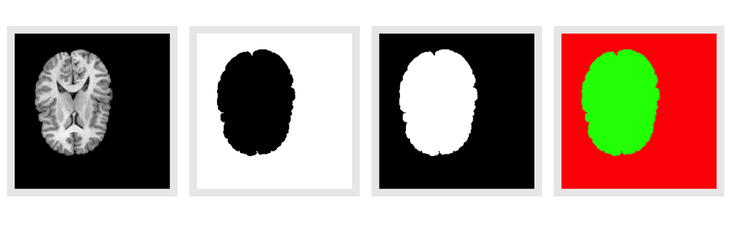

```r
cowplot::plot_grid(p20, p21, p22, p23, ncol = 4)
```

## U-Net model for image segmentation

Create a Keras model of the U-net deep learning architecture for image segmentation.

```r
# numberOfLabels <- 2

model <- createUnetModel2D(
  inputImageSize = c(dim(domainImage), 1),
  numberOfOutputs = numberOfLabels,
  numberOfLayers = 4,
  numberOfFiltersAtBaseLayer = 32,
  # dropoutRate = 0.5,
  mode = "classification"
)
```

```r
summary(model)
```

```
#> Model: "model"
#> ________________________________________________________________________________
#> Layer (type)              Output Shape      Param #  Connected to
#> ================================================================================
#> input_1 (InputLayer)      [(None, 256, 256, 0
#> ________________________________________________________________________________
#> conv2d (Conv2D)           (None, 256, 256,  320      input_1[0][0]
#> ________________________________________________________________________________
#> conv2d_1 (Conv2D)         (None, 256, 256,  9248     conv2d[0][0]
#> ________________________________________________________________________________
#> max_pooling2d (MaxPooling (None, 128, 128,  0        conv2d_1[0][0]
#> ________________________________________________________________________________
#> conv2d_2 (Conv2D)         (None, 128, 128,  18496    max_pooling2d[0][0]
#> ________________________________________________________________________________
#> conv2d_3 (Conv2D)         (None, 128, 128,  36928    conv2d_2[0][0]
#> ________________________________________________________________________________
#> max_pooling2d_1 (MaxPooli (None, 64, 64, 64 0        conv2d_3[0][0]
#> ________________________________________________________________________________
#> conv2d_4 (Conv2D)         (None, 64, 64, 12 73856    max_pooling2d_1[0][0]
#> ________________________________________________________________________________
#> conv2d_5 (Conv2D)         (None, 64, 64, 12 147584   conv2d_4[0][0]
#> ________________________________________________________________________________
#> max_pooling2d_2 (MaxPooli (None, 32, 32, 12 0        conv2d_5[0][0]
#> ________________________________________________________________________________
#> conv2d_6 (Conv2D)         (None, 32, 32, 25 295168   max_pooling2d_2[0][0]
#> ________________________________________________________________________________
#> conv2d_7 (Conv2D)         (None, 32, 32, 25 590080   conv2d_6[0][0]
#> ________________________________________________________________________________
#> conv2d_transpose (Conv2DT (None, 32, 32, 12 131200   conv2d_7[0][0]
#> ________________________________________________________________________________
#> up_sampling2d (UpSampling (None, 64, 64, 12 0        conv2d_transpose[0][0]
#> ________________________________________________________________________________
#> concatenate (Concatenate) (None, 64, 64, 25 0        up_sampling2d[0][0]
#>                                                      conv2d_5[0][0]
#> ________________________________________________________________________________
#> conv2d_8 (Conv2D)         (None, 64, 64, 12 295040   concatenate[0][0]
#> ________________________________________________________________________________
#> conv2d_9 (Conv2D)         (None, 64, 64, 12 147584   conv2d_8[0][0]
#> ________________________________________________________________________________
#> conv2d_transpose_1 (Conv2 (None, 64, 64, 64 32832    conv2d_9[0][0]
```

[output cut: 12 more lines]

```
#> up_sampling2d_2 (UpSampli (None, 256, 256,  0        conv2d_transpose_2[0][0]
#> ________________________________________________________________________________
#> concatenate_2 (Concatenat (None, 256, 256,  0        up_sampling2d_2[0][0]
#>                                                      conv2d_1[0][0]
#> ________________________________________________________________________________
#> conv2d_12 (Conv2D)        (None, 256, 256,  18464    concatenate_2[0][0]
#> ________________________________________________________________________________
#> conv2d_13 (Conv2D)        (None, 256, 256,  9248     conv2d_12[0][0]
#> ________________________________________________________________________________
#> conv2d_14 (Conv2D)        (None, 256, 256,  66       conv2d_13[0][0]
#> ================================================================================
#> Total params: 1,925,058
#> Trainable params: 1,925,058
#> Non-trainable params: 0
#> ________________________________________________________________________________
```

## Loss and validation functions

```r
metric_multilabel_dice_coefficient_2d <-
  custom_metric(
    "multilabel_dice_coefficient_2d",
    multilabel_dice_coefficient_2d
  )

loss_dice <- function(y_true, y_pred) {
  -multilabel_dice_coefficient_2d(y_true, y_pred)
}
attr(loss_dice, "py_function_name") <- "multilabel_dice_coefficient_2d"
```

```r
model %>% compile(
  loss = loss_dice,
  optimizer = optimizer_adam(lr = 0.0001),
  metrics = metric_multilabel_dice_coefficient_2d
)
```

```
#>
#> y_true: Tensor("conv2d_14_target:0", shape=(None, None, None, None), dtype=float32)
#> y_pred: Tensor("conv2d_14/Identity:0", shape=(None, 256, 256, 2), dtype=float32)
#>
#> y_true: Tensor("conv2d_14_target:0", shape=(None, None, None, None), dtype=float32)
#> y_pred: Tensor("conv2d_14/Identity:0", shape=(None, 256, 256, 2), dtype=float32)
```

```r
track <- model %>% fit(
  X_train, Y_train,
  epochs = 40,
  batch_size = 6, verbose = 1, shuffle = TRUE,
  callbacks = list(
    # callback_model_checkpoint(
    #   "unetModelInterimWeights.h5",
    #   monitor = 'val_loss',
    #   save_best_only = TRUE
    # ),
    callback_reduce_lr_on_plateau(
      monitor = "val_loss",
      factor = 0.1
    )
  ),
  validation_split = 0.2
)
```

[output not shown]

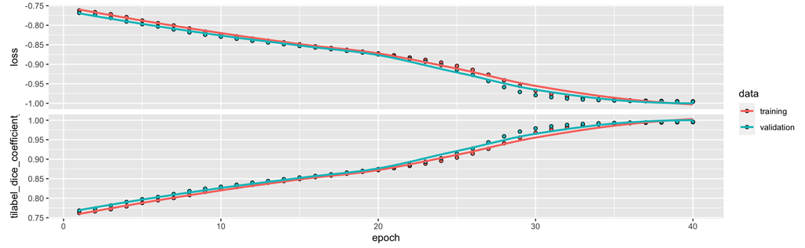

```r
plot(track)
```

## Prediction

```r
Y_predicted = model %>% predict(X_train)
str(Y_predicted)
```

```
#>  num [1:6, 1:256, 1:256, 1:2] 0.534 0.534 0.534 0.534 0.534 ...
```

```r
Yd_predicted <- decodeUnet(Y_predicted, domainImage) # list
str(Yd_predicted[[6]])
```

```
#> List of 2
#>  $ :Formal class 'antsImage' [package "ANTsRCore"] with 6 slots
#>   .. ..@ pixeltype : chr "float"
#>   .. ..@ dimension : int 2
#>   .. ..@ components: int 1
#>   .. ..@ pointer   :<externalptr>
#>   .. ..@ isVector  : logi FALSE
#>   .. ..@ filename  : chr ""
#>  $ :Formal class 'antsImage' [package "ANTsRCore"] with 6 slots
#>   .. ..@ pixeltype : chr "float"
#>   .. ..@ dimension : int 2
#>   .. ..@ components: int 1
#>   .. ..@ pointer   :<externalptr>
#>   .. ..@ isVector  : logi FALSE
#>   .. ..@ filename  : chr ""
```

- Hansjörg Neth. [Data Science for Psychologists](https://bookdown.org/hneth/ds4psy/D-2-apx-colors-essentials.html)

ggplot2 histograms.

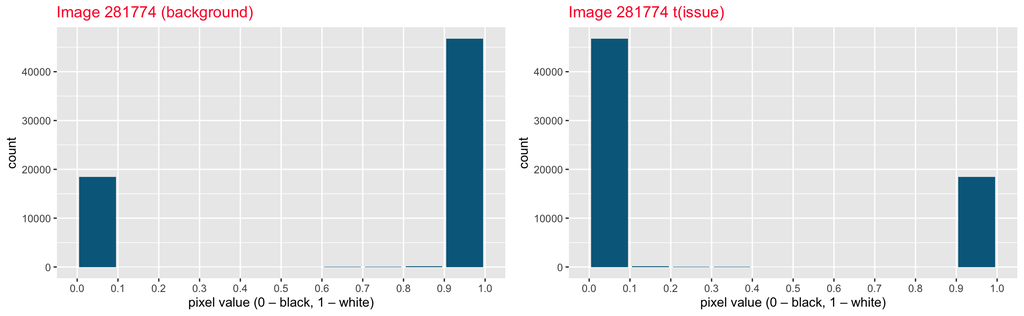

```r
yd6_pred <- Yd_predicted[[6]]

cowplot::plot_grid(
  pixels_hist(yd6_pred[[1]], "281774 (background)"),
  pixels_hist(yd6_pred[[2]], "281774 t(issue)"),
  ncol = 2
)
```

```r
p33 <- plotColor(as.antsImage(X_train[6,,,1]))
p34 <- plotColor(yd6_pred[[1]])
p35 <- plotColor(yd6_pred[[2]])
p36 <- pixels_hist(yd6_pred[[2]], "281774 (tissue pred)")

# p36 <- plotColor(list(yd6_pred[[1]], black3, yd6_pred[[2]]))
```

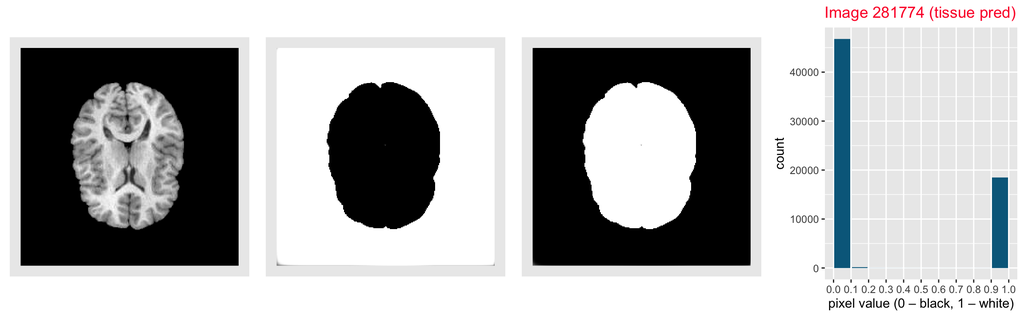

```r
cowplot::plot_grid(p33, p34, p35, p36, ncol = 4)
```